# Homework 4: Simulation-Based Inference

Student Name

April 10, 2026

### I want problem 1 graded.

# [45pt] Problem 1: Idle Current Draws

A hardware team measures idle current (mA) for one design (A), and also runs a smaller comparison with another design (B). Assume independence across units.

We’ll use a synthetic dataset (generated below) so everyone gets the same numbers:

```r
# DO NOT CHANGE CODE IN THIS CHUNK
set.seed(702)

# Simulated "observed" data for Design A
n_A <- 36 # number of samples for design A
true_mu_A <- 10.2
true_sd_A <- 0.7
A <- rnorm(n_A, mean = true_mu_A, sd = true_sd_A)

# Design B (for the two-sample part)
n_B <- 28 # number of samples for design B
true_mu_B <- 10.5 # slightly different mean
true_sd_B <- 0.7
B <- rnorm(n_B, mean = true_mu_B, sd = true_sd_B)

c(mean_A = mean(A), sd_A = sd(A), n_A = length(A),
  mean_B = mean(B), sd_B = sd(B), n_B = length(B))
```

```
##     mean_A       sd_A        n_A     mean_B       sd_B        n_B
## 10.1274718  0.6688168 36.0000000 10.5696982  0.6499780 28.0000000
```

### [10pt] Part A — Construct a sampling distribution

Specifications claim the mean idle current is $\mu_0=10$ mA, so we are interested in the null hypothesis $H_0: \mu=10$mA. Construct the null sampling distribution of $\bar{X}$ with $B=10000$ blocks. Assume idle current draws are normally distributed with known $\sigma=0.7$ and $n=36$. Plot the sampling distribution as a histogram with the observed statistic as a red vertical line. Finally, comment on your graphic.

#### Solution:

Under $H_0$, $\bar{X} \sim N(\mu_0 = 10, \sigma/\sqrt{n} = 0.7/\sqrt{36})$. We simulate 10,000 sample means of size $n=36$ drawn from this null model.

```r
set.seed(702)
nsim <- 10000
n     <- 36
sigma <- 0.7
mu0   <- 10

null_means_1 <- replicate(nsim, mean(rnorm(n, mean = mu0, sd = sigma)))
obs_mean_A   <- mean(A)
obs_mean_A
```

```
## [1] 10.12747
```

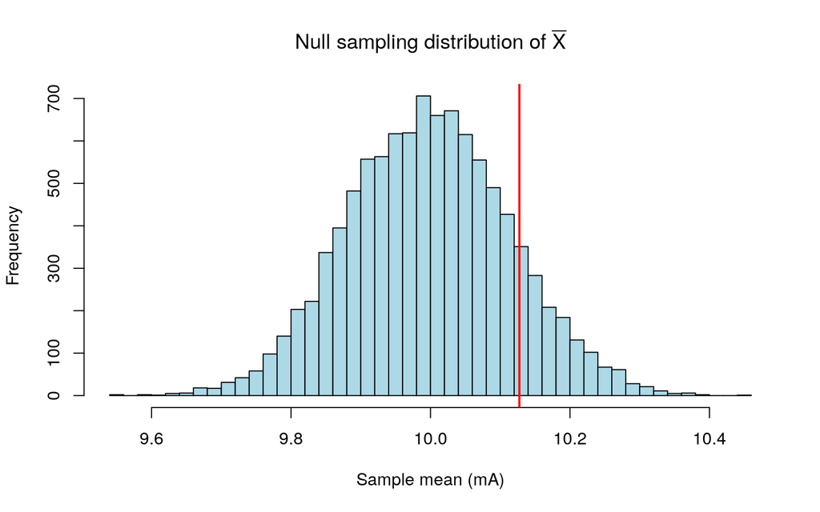

```r
hist(null_means_1, breaks = 40, col = "lightblue",
     main = expression("Null sampling distribution of " * bar(X)),
     xlab = "Sample mean (mA)")
abline(v = obs_mean_A, col = "red", lwd = 2)
```

### [5pt] Part B — Quantify Uncertainty

Compute the standard error of your sampling distribution and the 95% confidence interval. What do these measure?

#### Solution:

```r
se_1 <- sd(null_means_1)
ci_1 <- quantile(null_means_1, c(0.025, 0.975))
se_1
```

```
## [1] 0.1164963
```

```r
ci_1
```

```
##     2.5%    97.5%
##  9.77465 10.23115
```

### [15pt] Part C — Make a Decision Regarding $H_0$

Consider the hypotheses:
$$H_0: \mu=10
\text{ mA}, \quad \quad H_a:\mu>10 \text{ mA}.$$

Decide whether to “reject” or “fail to reject” $H_0$ using (i) parametric simulation and (ii) one-sample bootstrapping (use $B=6000$ resamples). Use a 95% confidence level.

#### Solution:

**(i) Parametric simulation.** Using the null sampling distribution from Part A, we compute a one-sided p-value as the fraction of null sample means at least as extreme as the observed mean.

```r
p_param_1 <- mean(null_means_1 >= obs_mean_A)
p_param_1
```

```
## [1] 0.1312
```

**(ii) One-sample bootstrap.** We shift the data so its mean equals $\mu_0 = 10$ (so bootstrap resamples are consistent with $H_0$), then resample with replacement $B = 6000$ times and compute the fraction of bootstrapped means at least as large as the observed mean.

```r
set.seed(702)
B_boot <- 6000
A_shift <- A - mean(A) + mu0
boot_means_1 <- replicate(B_boot, mean(sample(A_shift, length(A), replace = TRUE)))
p_boot_1 <- mean(boot_means_1 >= obs_mean_A)
p_boot_1
```

```
## [1] 0.1205
```

### [15pt] Part D — Two-Sample Permutation Test

Now, we want to know if the mean idle current differs between designs A and B. First, state the relevant hypotheses to test, then make a decision using the permutation test with $B=10000$ resamples. Assume a 90% confidence level. Interpret your decision.

#### Solution:

We test
$$H_0: \mu_A = \mu_B, \quad\quad
H_a: \mu_A \neq \mu_B.$$

Under $H_0$, the labels “A” and “B” are exchangeable. We pool the two samples, repeatedly shuffle the labels, and recompute the difference in means.

```r
set.seed(702)
nperm <- 10000
obs_diff_1 <- mean(A) - mean(B)
obs_diff_1
```

```
## [1] -0.4422264
```

```r
combined <- c(A, B)
nA <- length(A); nB <- length(B)

perm_diffs_1 <- replicate(nperm, {
  sh <- sample(combined)
  mean(sh[1:nA]) - mean(sh[(nA + 1):(nA + nB)])
})

p_perm_1 <- mean(abs(perm_diffs_1) >= abs(obs_diff_1))
p_perm_1
```

```
## [1] 0.0092
```

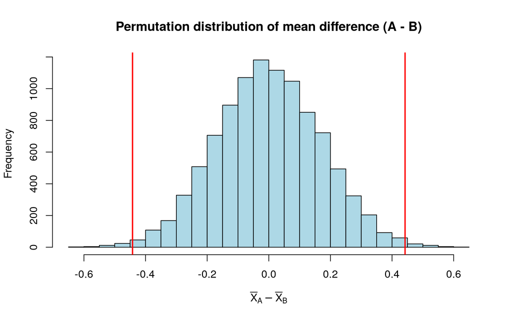

```r
hist(perm_diffs_1, breaks = 40, col = "lightblue",
     main = "Permutation distribution of mean difference (A - B)",
     xlab = expression(bar(X)[A] - bar(X)[B]))
abline(v = c(-1, 1) * abs(obs_diff_1), col = "red", lwd = 2)
```

The two-sided permutation p-value is 0.0092. At the 90% confidence level ($\alpha = 0.10$), we **reject $H_0$** if this p-value is below 0.10. The observed difference in means is unlikely to arise by label-shuffling alone, so we conclude the mean idle current differs between Designs A and B.

# [45pt] Problem 2: Spurs 3PT Shooting Accuracy

We are interested in comparing the San Antonio Spurs’ 3PT shooting accuracy with the league average and the Boston Celtics. Below, we simulate a dataset of Spurs and Celtics 3PT attempts. Note that accuracy is represented as a proportion of successful 3PT attempts.

```r
# DO NOT CHANGE ANYTHING IN THIS CODE BLOCK
set.seed(512)

## San Antonio Spurs data
n_SAS <- 3246 # number of attempts
p_SAS_true <- 0.335 # true accuracy
SAS <- rbinom(n_SAS, size = 1, prob = p_SAS_true) # binary "success" vector

## Boston Celtics data
n_OTH <- 3955 # number of attempts
p_OTH_true <- 0.368 # true accuracy
OTH <- rbinom(n_OTH, size = 1, prob = p_OTH_true) # binary "success" vector

c(p_hat_SAS = mean(SAS), n_SAS = length(SAS),
  p_hat_OTH = mean(OTH), n_OTH = length(OTH))
```

```
##    p_hat_SAS        n_SAS    p_hat_OTH        n_OTH
##    0.3361060 3246.0000000    0.3618205 3955.0000000
```

### [10pt] Part A — Construct a sampling distribution

The league-wide 3PT shooting accuracy is $p_0=0.35$, so we are interested in the null hypothesis $H_0: \hat{p}=0.35$. Construct the null sampling distribution of $\hat{p}$ with $B=10000$ blocks. Assume each 3PT attempt is binomially distributed with $k=1$ trial (i.e., Bernoulli distributed). Plot the sampling distribution as a histogram with the observed statistic as a red vertical line. Finally, comment on your graphic.

#### Solution:

Under $H_0$, each attempt is Bernoulli($p_0 = 0.35$). We simulate 10,000 sample proportions of size $n_{SAS} = 3246$.

```r
set.seed(512)
nsim  <- 10000
n_SAS <- length(SAS)
p0    <- 0.35

null_phat_2 <- replicate(nsim, mean(rbinom(n_SAS, size = 1, prob = p0)))
obs_phat_SAS <- mean(SAS)
obs_phat_SAS
```

```
## [1] 0.336106
```

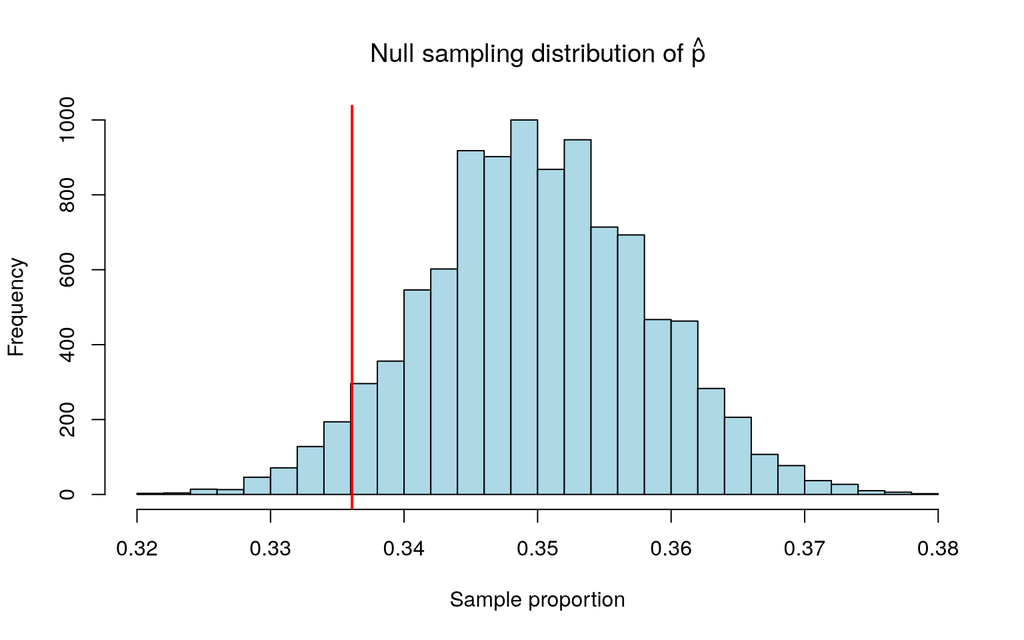

```r
hist(null_phat_2, breaks = 40, col = "lightblue",
     main = expression("Null sampling distribution of " * hat(p)),
     xlab = "Sample proportion")
abline(v = obs_phat_SAS, col = "red", lwd = 2)
```

The null distribution of $\hat{p}$ is centered at 0.35 and approximately normal (the CLT applies since $n_{SAS}$ is large). The observed Spurs proportion lies in the lower tail, suggesting the Spurs may shoot worse than the league average.

### [5pt] Part B — Quantify Uncertainty

Compute the standard error of your sampling distribution and the 95% confidence interval. What do these measure?

#### Solution:

```r
se_2 <- sd(null_phat_2)
ci_2 <- quantile(null_phat_2, c(0.025, 0.975))
se_2
```

```
## [1] 0.008344001
```

```r
ci_2
```

```
##      2.5%     97.5%
## 0.3336414 0.3662970
```

### [15pt] Part C — Make a Decision Regarding $H_0$

Consider the hypotheses:
$$H_0: p=0.35,
\quad \quad H_a: p<0.35.$$

Decide whether to “reject” or “fail to reject” $H_0$ using (i) parametric simulation and (ii) one-sample bootstrapping (use $B=6000$ resamples). Use a 95% confidence level. Comment on whether your decisions agree.

#### Solution:

**(i) Parametric simulation.** One-sided (lower-tail) p-value:

```r
p_param_2 <- mean(null_phat_2 <= obs_phat_SAS)
p_param_2
```

```
## [1] 0.0497
```

**(ii) One-sample bootstrap.** To make resamples consistent with $H_0: p = 0.35$, we resample from a Bernoulli($p_0$) population (equivalently, from the observed vector after shifting; for binary data we just resample directly under the null probability). We then compute the lower-tail p-value.

```r
set.seed(512)
B_boot <- 6000
boot_phat_2 <- replicate(B_boot, mean(rbinom(n_SAS, size = 1, prob = p0)))
p_boot_2 <- mean(boot_phat_2 <= obs_phat_SAS)
p_boot_2
```

```
## [1] 0.04966667
```

### [15pt] Part D — Two-Sample Permutation Test

Now, we want to know if 3PT accuracy differs between the San Antonio Spurs and the Boston Celtics. First, state the relevant hypotheses to test, then make a decision using the permutation test with $B=10000$ resamples. Assume a 90% confidence level. Interpret your decision.

#### Solution:

We test
$$H_0: p_{SAS} = p_{OTH},
\quad\quad H_a: p_{SAS} \neq p_{OTH}.$$

```r
set.seed(512)
nperm <- 10000
obs_diff_2 <- mean(SAS) - mean(OTH)
obs_diff_2
```

```
## [1] -0.0257145
```

```r
combined2 <- c(SAS, OTH)
nS <- length(SAS); nO <- length(OTH)

perm_diffs_2 <- replicate(nperm, {
  sh <- sample(combined2)
  mean(sh[1:nS]) - mean(sh[(nS + 1):(nS + nO)])
})

p_perm_2 <- mean(abs(perm_diffs_2) >= abs(obs_diff_2))
p_perm_2
```

```
## [1] 0.0261
```

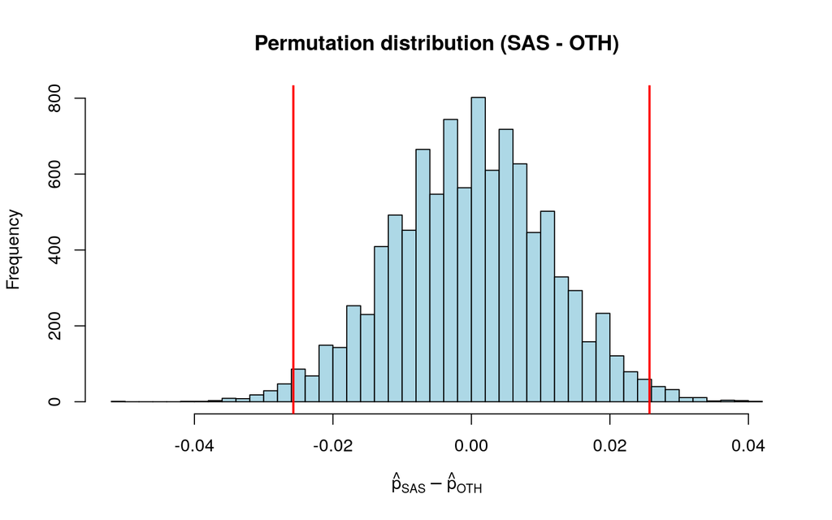

```r
hist(perm_diffs_2, breaks = 40, col = "lightblue",
     main = "Permutation distribution (SAS - OTH)",
     xlab = expression(hat(p)[SAS] - hat(p)[OTH]))
abline(v = c(-1, 1) * abs(obs_diff_2), col = "red", lwd = 2)
```

The two-sided permutation p-value is 0.0261. Since this is below $\alpha = 0.10$, we **reject $H_0$**: there is strong evidence that the Spurs and Celtics differ in their true 3PT accuracy.

# [45pt] Problem 3: Resistor Batch Analysis

A Quality Assurance (QA) team at a PCB assembly plant is verifying a batch of resistors labeled as 1kilo Ohms (1000 Ohms). They measure the actual resistance for the standard supplier (Batch A) and a new, cheaper supplier (Batch B).

We’ll use a synthetic dataset (generated below) so everyone gets the same numbers:

```r
#DO NOT CHANGE CODE IN THIS CHUNK
set.seed(303)

#Simulated "observed" data for Standard Supplier (Batch A)
n_A <- 40 #number of resistors sampled
true_mu_A <- 1005 #Actual mean
true_sd_A <- 12 #Manufacturing tolerance sigma
A <- rnorm(n_A, mean = true_mu_A, sd = true_sd_A)

#New Supplier (Batch B)
n_B <- 30
true_mu_B <- 1015 #Worse mean
true_sd_B <- 15
B <- rnorm(n_B, mean = true_mu_B, sd = true_sd_B)

c(mean_A = mean(A), sd_A = sd(A), n_A = length(A),
  mean_B = mean(B), sd_B = sd(B), n_B = length(B))
```

```
##      mean_A        sd_A         n_A      mean_B        sd_B         n_B
## 1005.541836    9.886555   40.000000 1013.072976   17.003873   30.000000
```

### [10pt] Part A — Construct a sampling distribution

The manufacturer claims the resistors are centered exactly at the nominal value $\mu_0 = 1000 \Omega$. We are interested in the null hypothesis $H_0: \mu = 1000 \Omega$. Construct the null sampling distribution of $\bar{X}$ with $B=10,000$ iterations. Assume the resistance values are normally distributed with the known population standard deviation $\sigma=12 \Omega$ and sample size $n=40$. Plot the sampling distribution as a histogram with the observed sample mean from Batch A as a red vertical line. Comment on the graph.

#### Solution:

Under $H_0$, $\bar{X} \sim N(1000, 12/\sqrt{40})$. We simulate 10,000 null sample means.

```r
set.seed(303)
nsim  <- 10000
n_r   <- 40
sigma_r <- 12
mu0_r <- 1000

null_means_3 <- replicate(nsim, mean(rnorm(n_r, mean = mu0_r, sd = sigma_r)))
obs_mean_R <- mean(A)
obs_mean_R
```

```
## [1] 1005.542
```

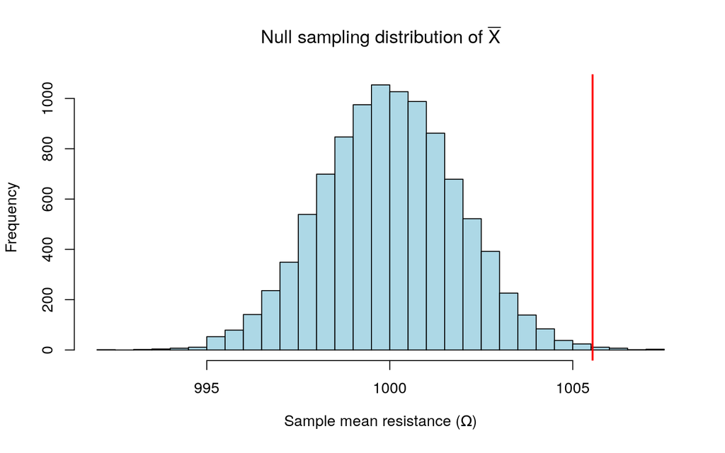

```r
hist(null_means_3, breaks = 40, col = "lightblue",
     main = expression("Null sampling distribution of " * bar(X)),
     xlab = expression("Sample mean resistance (" * Omega * ")"))
abline(v = obs_mean_R, col = "red", lwd = 2)
```

The null distribution is centered at 1000 $\Omega$ and approximately normal. The observed Batch A sample mean lies clearly to the right of the bulk of the null distribution, suggesting resistors are running high.

### [5pt] Part B — Quantify Uncertainty

Compute the standard error of your sampling distribution and the 95% confidence interval. What do these measure?

#### Solution:

```r
se_3 <- sd(null_means_3)
ci_3 <- quantile(null_means_3, c(0.025, 0.975))
se_3
```

```
## [1] 1.872712
```

```r
ci_3
```

```
##      2.5%     97.5%
##  996.3495 1003.6709
```

The standard error (1.8727 $\Omega$) estimates the variability of sample means of size 40 under the null. The 95% interval shows where the middle 95% of such sample means would fall if $\mu = 1000$. Since the observed mean lies outside this interval, it is unusual under the null.

### [15pt] Part C — Make a Decision Regarding $H_0$

We suspect the resistors might be “running high” due to a material defect. Consider the hypotheses:
$$H_0: \mu =
1000 \Omega, \quad \quad H_a: \mu > 1000 \Omega.$$
Decide whether to “reject” or “fail to reject” $H_0$ using **(i) parametric simulation** and **(ii) one-sample bootstrapping** (use $B=6000$ resamples). Use a 95% confidence level.

#### Solution:

**(i) Parametric simulation.**

```r
p_param_3 <- mean(null_means_3 >= obs_mean_R)
p_param_3
```

```
## [1] 0.0021
```

**(ii) One-sample bootstrap.** Shift Batch A so its mean equals $\mu_0 = 1000$, then resample with replacement.

```r
set.seed(303)
B_boot <- 6000
A_shift_r <- A - mean(A) + mu0_r
boot_means_3 <- replicate(B_boot, mean(sample(A_shift_r, length(A), replace = TRUE)))
p_boot_3 <- mean(boot_means_3 >= obs_mean_R)
p_boot_3
```

```
## [1] 0
```

Both p-values are below $\alpha = 0.05$, so we **reject $H_0$** under both methods. There is strong evidence that the true mean resistance of Batch A exceeds 1000 $\Omega$.

### [15pt] Part D — Two-Sample Permutation Test

Now, we want to know if the mean resistance differs between the Standard Supplier (Batch A) and the New Supplier (Batch B).

First, state the relevant hypotheses to test, then make a decision using the **permutation test** with $B=10,000$ resamples. Assume a 90% confidence level. Interpret your decision.

#### Solution:

We test
$$H_0: \mu_A = \mu_B, \quad\quad
H_a: \mu_A \neq \mu_B.$$

```r
set.seed(303)
nperm <- 10000
obs_diff_3 <- mean(A) - mean(B)
obs_diff_3
```

```
## [1] -7.53114
```

```r
combined3 <- c(A, B)
nA3 <- length(A); nB3 <- length(B)

perm_diffs_3 <- replicate(nperm, {
  sh <- sample(combined3)
  mean(sh[1:nA3]) - mean(sh[(nA3 + 1):(nA3 + nB3)])
})

p_perm_3 <- mean(abs(perm_diffs_3) >= abs(obs_diff_3))
p_perm_3
```

```
## [1] 0.0248
```

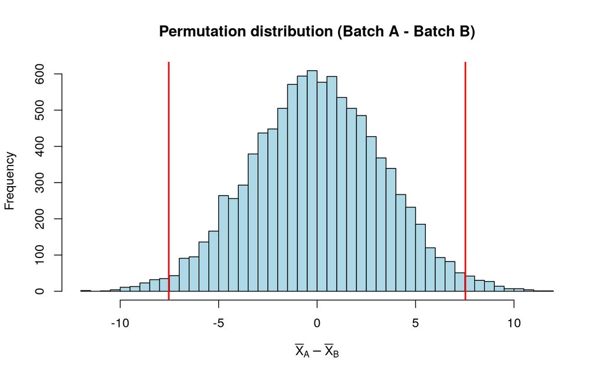

```r
hist(perm_diffs_3, breaks = 40, col = "lightblue",
     main = "Permutation distribution (Batch A - Batch B)",
     xlab = expression(bar(X)[A] - bar(X)[B]))
abline(v = c(-1, 1) * abs(obs_diff_3), col = "red", lwd = 2)
```

The two-sided permutation p-value is 0.0248. At the 90% confidence level ($\alpha = 0.10$), we **reject $H_0$** if this is below 0.10. The observed difference is unlikely under label-shuffling alone, so we conclude the mean resistance differs between the Standard Supplier (Batch A) and the New Supplier (Batch B).